# advanced_sr

#### 2.2.1 plot

To further understand the relationship it can also be useful to plot the E/P lines. Here it would be possible to identify outliers as well (the treatment of outliers is explained in the next advanced part of the script)

```
    Task 2.2.1 Plot the E/P relationship twice. Once with fitting a linear line and once fitting a quadratic line onto the squatterplot.
```

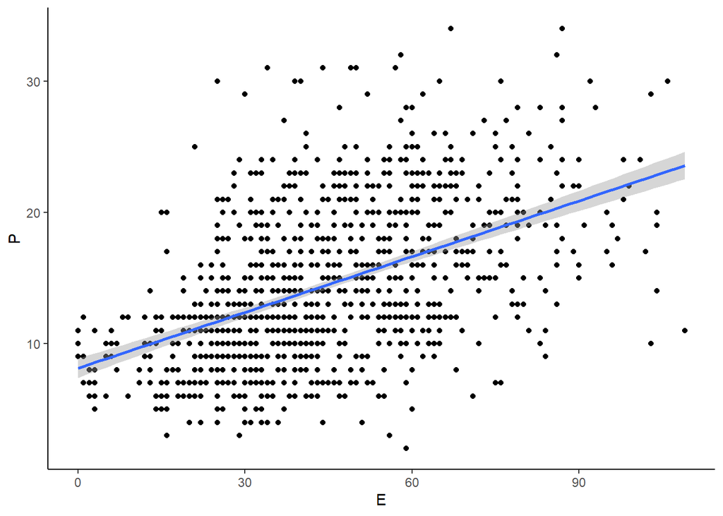

```r
# plot a linear relationship
plotlin <-  ds %>%
  ggplot(aes(x = E, y = P)) +
  geom_point() +
  labs(x="E", y="P") +
  # adding an EP line based on linear modelling
  geom_smooth(method = "lm")+
  # this just makes it prettier
  theme_classic()

plotlin
```

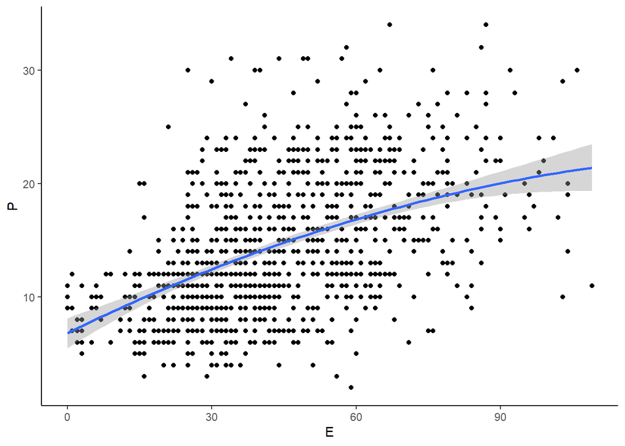

```r
# plot a quadratic relationship
plotquad <- ds %>%
  ggplot(aes(x = E, y = P)) +
  geom_point() +
  labs(x="E", y="P") +
  # adding an EP line based on a quadratic relationship
  geom_smooth(formula = y ~ poly(x, 2, raw=TRUE))+
  theme_classic()

plotquad
```

### 2.3 explained variance

As a way of testing the quality of your model you can analyse the explained variance of the model

```
  Task 2.3 Calculate the R2 of the linear and quadratic model we have just compared.
```

```r
# R squared of the linear model previously calculated
summary(EP_lin)$adj.r.squared
```

```
## [1] 0
```

```r
# R squared of the quadratic model previously calculated
summary(EP_quad)$adj.r.squared
```

```
## [1] 0
```

### 2.4 decide on model

Things to consider

*Are you interested in an average time period or single timepoints?* Is your study concluded or not? *Which model best describes the relationship (linear or quadratic?)* Are there outliers that could be affecting the fit? (See advanced script)

## 3 calculate SR score

We will calculate different SR scores heres to showcase how the SR score is calculated.

### 3.1 single time points

If you want to calculate SR scores for each assessment you need to base it on the multilevel model. Our assessment revealed, that the linear model best describes the relationship.

#### 3.1.1 extract intercept and slope

We therefore need to extract the intercept and slope from the multilevel model.

```
  Task 3.1.1 Save the intercept and slope from the multilevel model (2.1.2) in separate objects.
```

```r
intercept_multi  <- EP_multi$coefficients[1]
E_slope_multi  <- EP_multi$coefficients[2]
```

#### 3.1.2 predicted P

We use the extracted intercept and slope to calculate the predicted P based on their E, using a linear equation (y=slope*x+intercept)

The E in the equation needs to be scaled.

```
  Task 3.1.2 Calculate the predicted P based on a linear equation, store it as a variable in the dataset
```

```r
 ds$P_pred_multi<- intercept_multi  + scale(ds$E)*E_slope_multi
```

#### 3.1.3 SR score

The SR score is then the difference between the actual P and the predicted P, that is the residual of each P to the normative E/P line.

```
  Task 3.1.3 Calculate the difference between actual P and predicted P for each participant
```

```r
 ds$SR<- scale(scale(ds$P) - ds$P_pred_multi)
```

### 3.2 over entire time period

#### 3.2.1 extract intercept and slope

First, we need to extract the intercept and slopes (in a quadratic model there are two slopes)

```r
intercept_t1t6  <- EP_quad$coefficients[1]
E_slope_b  <- EP_quad$coefficients[2]
E_slope_a  <- EP_quad$coefficients[3]
```

#### 3.1.2 predicted P

We then calculate the predicted P base on the quadratic equation. (y=slopeA*x^2+slopeB*x+intercept)

```
  Task 3.1.2 Calculate the predicted P based on a quadratic equation, store it as a variable in the dataset
```

```r
 ds$P_t1.t6_pred <- intercept_t1t6  + scale(ds$E_t1.t6)*E_slope_b  + (scale(ds$E_t1.t6)^2)*E_slope_a
```

#### 3.1.3 SR score

We then again, calculate the difference between actual P and predicted P.

```
  Task 3.1.3 Calculate the difference between actual P and predicted P for each participant
```

```r
 ds$SR_t1.t6<- scale(scale(ds$P_t1.t6) - ds$P_t1.t6_pred)
```

## 4 Why SR? - SR over time

As an illustration as to why the SR score can offer valuable insights into resilience, we will now examine E, P and SR over time.

```
  Task 4: Plot E, P and SR over all 6 time points (separate plots for each variable). Then test the difference between time point 1 and time point 6 to see whether E, P and SR change significantly over time. (you could do this within your plot with ggsignif)
```

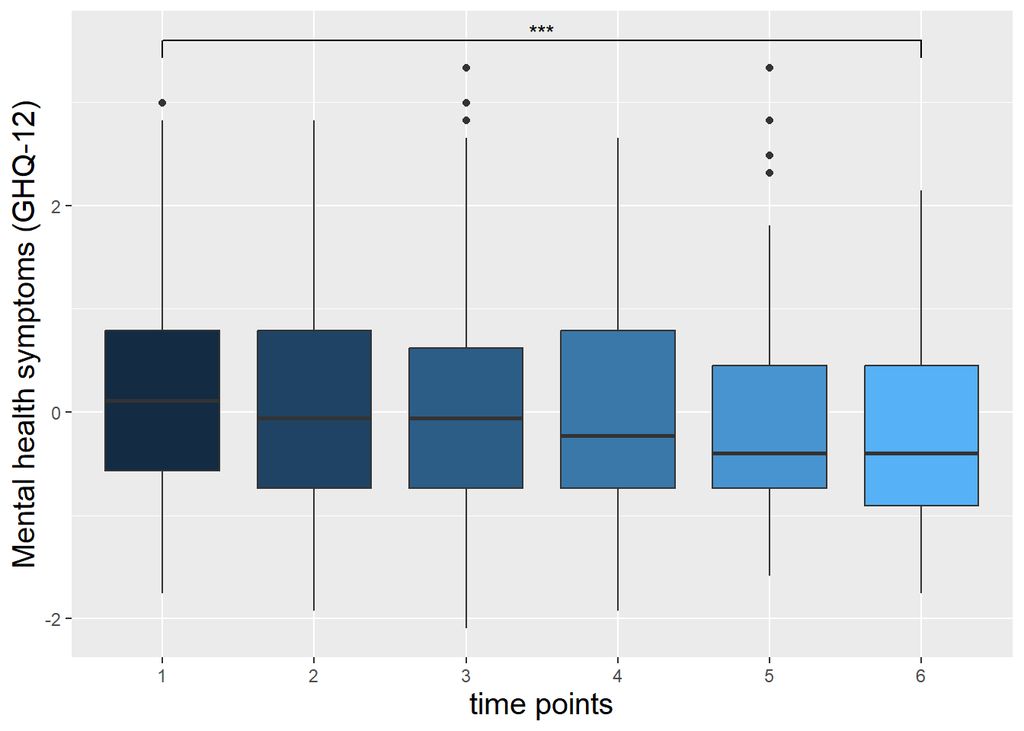

```r
p_plot <-  ds %>%
  ggplot(
    aes(
      y = scale(P),
      x = factor(beep),
      fill = beep)
    ) +
  geom_boxplot() +
  ggsignif::geom_signif(comparisons = list(c(1,6)),
                        test =  t.test,
                        map_signif_level = TRUE,
                        step_increase = 0.055,
                        vjust = 0.4) +
  xlab("time points")+
  ylab("Mental health symptoms (GHQ-12)") +
  theme(legend.position = "none",
        axis.title = element_text(size = 15))

e_plot <-  ds %>%
  ggplot(
    aes(
      y = scale(E),
      x = factor(beep),
      fill = beep)
    ) +
  geom_boxplot() +
  ggsignif::geom_signif(comparisons = list(c(1,6)),
                        test =  t.test,
                        map_signif_level = TRUE,
                        step_increase = 0.055,
                        vjust = 0.4) +
  xlab("time points")+
  ylab("Stressor exposure (E)") +
  theme(legend.position = "none",
        axis.title = element_text(size = 15))

sr_plot <-  ds %>%
  ggplot(
    aes(
      y = SR,
      x = factor(beep),
      fill = beep)
    ) +
  geom_boxplot() +
  ggsignif::geom_signif(comparisons = list(c(1,6)),
                        test =  t.test,
                        map_signif_level = TRUE,
                        step_increase = 0.055,
                        vjust = 0.4) +
  xlab("time points")+
  ylab("Stressor reactivity (SR)") +
  theme(legend.position = "none",
        axis.title = element_text(size = 15))

p_plot
```

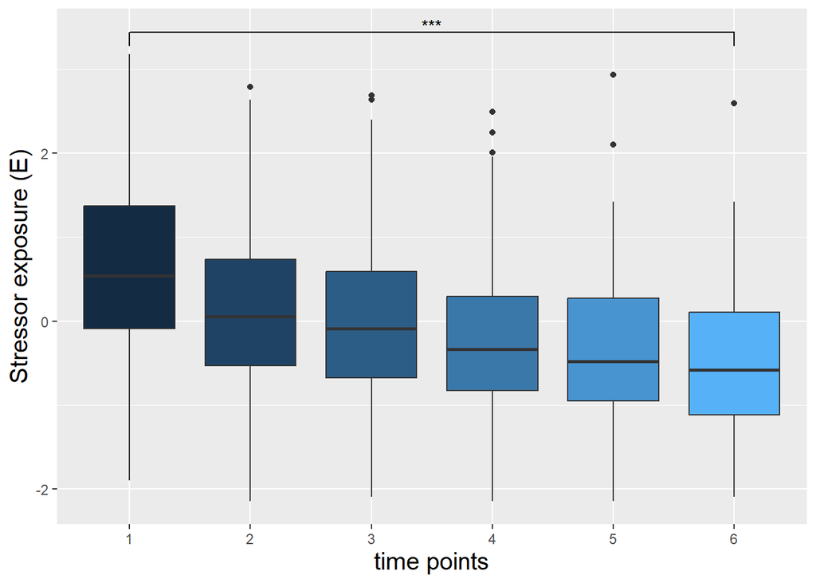

```r
e_plot
```

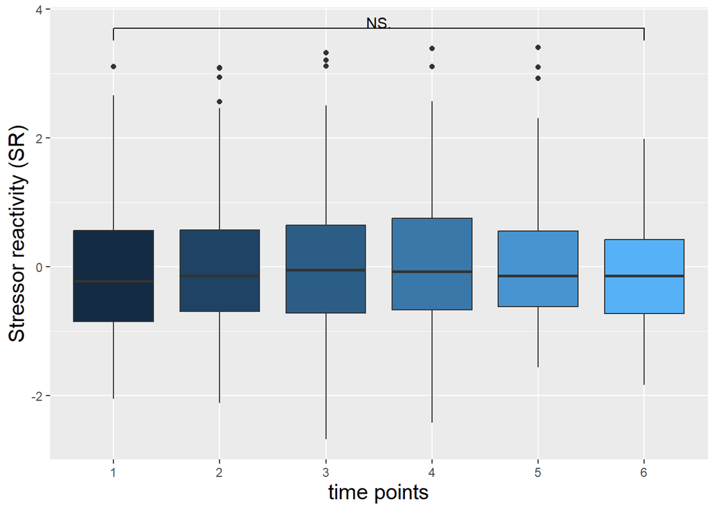

```r
sr_plot
```

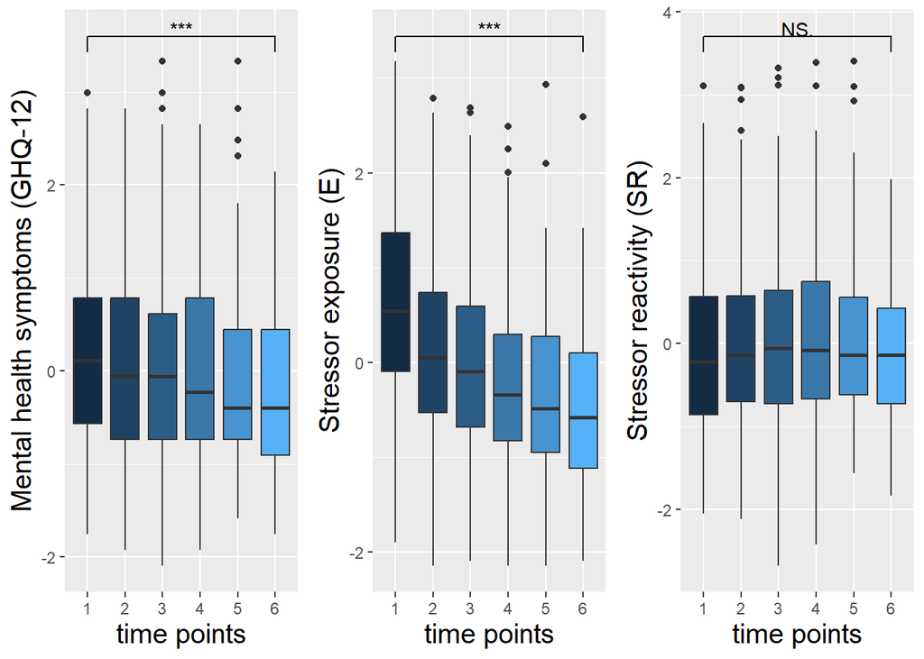

```r
ggpubr::ggarrange(p_plot, e_plot, sr_plot, nrow = 1)
```

We can see that the change and E and P are significant, but SR is not. Likely the changes in P are explained by changes in E, by controlling for E we can disentangle the causes of these changes.

# Part B: SR Score advanced

By now, you know how to build you basic SR score in cross-sectional and longitudinal studies. You also already know how to select the right E score and fit the optimal E-P line (linear or quadratic).

In this section, you will explore ways to fine-tune your SR score to your study design (i.e., long-term studies with long measurement spacing; comprehensive stressor list or subsets of stressors) and collected data (Outliers and distributions). Many of these approaches are sample and study specific and it is often a custom decision which approach you will use for your sample

For the advanced script, we continue working with P/P_t1.t6 and E/E_t1.t6

We work with E for simplicity, but you can also work with E_scaled, which showed the strongest relationship to P.

## 1 SR in long-term studies

### 1.1 sliding windows

Sometimes, if we want to calculate an SR score in ongoing studies, it is helpful to calculate sliding windows. For example, if we collect E at long intervals (several weeks or months between measurements), a single measurement of E may incompletely represent the stressors regularly faced by a given person. Calculating sliding windows e.g. as averages of 3 measurements can help create more representative measures.

This rationale is described in detail in the FRESHMO paper [Kalisch et al.](https://www.frontiersin.org/articles/10.3389/fpsyg.2021.710493).

#### 1.1.1 P & E sliding windows

```
  Task 1.1.1 Calculate the average P and E scores for each 3-beep intervals (i.e., beep 1-3, beep 2-4, etc)
```

```r
# initiate empty variables
ds$Mean.P_sliding<-NA
ds$Mean.E_sliding<-NA
ds$SR_sliding <- NA

#beep 1-3
ds$Mean.P_sliding[which(ds$beep<4)] <-
  calc.mean(P, subject.ID, data=ds[which(ds$beep<4),], na.rm = T, expand=TRUE)
ds$Mean.E_sliding[which(ds$beep<4)] <-
  calc.mean(E, subject.ID, data=ds[which(ds$beep<4),], na.rm = T, expand=TRUE)

#beep 2-4
ds$Mean.P_sliding[which(ds$beep>1 & ds$beep<5)] <-
  calc.mean(P, subject.ID, data=ds[which(ds$beep>1 & ds$beep<5),], na.rm = T, expand=TRUE)
ds$Mean.E_sliding[which(ds$beep>1 & ds$beep<5)] <-
  calc.mean(E, subject.ID, data=ds[which(ds$beep>1 & ds$beep<5),], na.rm = T, expand=TRUE)

#beep 3-5
ds$Mean.P_sliding[which(ds$beep>2 & ds$beep<6)] <-
  calc.mean(P, subject.ID, data=ds[which(ds$beep>2 & ds$beep<6),], na.rm = T, expand=TRUE)
ds$Mean.E_sliding[which(ds$beep>2 & ds$beep<6)] <-
  calc.mean(E, subject.ID, data=ds[which(ds$beep>2 & ds$beep<6),], na.rm = T, expand=TRUE)

#beep 4-6
ds$Mean.P_sliding[which(ds$beep>3)] <-
  calc.mean(P, subject.ID, data=ds[which(ds$beep>3),], na.rm = T, expand=TRUE)
ds$Mean.E_sliding[which(ds$beep>3)] <-
  calc.mean(E, subject.ID, data=ds[which(ds$beep>3),], na.rm = T, expand=TRUE)
```

#### 1.1.2 Calculate SR

Now, calculate the SR score for the respective sliding windows. Note that since we neither have a multilevel model nor quadratic effects, we do not need to go the round-about way of extracting intercept and slope and calculating the predicted scores. Instead, the residuals of the simple linear E-P line are the SR scores.

```
  Task 1.1.2a  Calculate the SR score for the first sliding interval
    * Subset the first sliding interval and save in a separate variable
    * Fit a linear E-P model to the average P and E scores in this interval
    * Save the scaled residuals of this model and add to the original data frame
```

```r
# You can use a separate data frame curset to join by ID, which makes sure the order is not messed up

# We can just subset the data frame at the first beep, as we saved sliding windows in the data frame always respective to the first beep of the window
curset = subset(ds, beep==1)

# fit a linear model in the subset
m1 <- summary(lm(scale(Mean.P_sliding)~scale(Mean.E_sliding),data= curset))

# extract scaled residuals as the SR score
curset$SR_1 <-scale(resid(m1))

# save in the original data frame ds
ds$SR_sliding[which(ds$beep==1)] <-scale(resid(m1))

# in addition to a variable "sliding" that combines all sliding scores, we also save the specific sliding scores per interval in a variable:
ds <- join(ds, curset[c("subject.ID", "SR_1", "beep")])
# note: sometimes, there can be conflicts between the packages "plyr" and "dplyr". Here, we need the package "plyr". If loading it above does not work, try reloading and potentially detaching dplyr

# library("plyr)
# detach("package:plyr", unload=TRUE)

# then rerun: ds <- join(ds, curset[c("subject.ID", "SR_1", "beep")])
```

```
  Task 1.1.2b  Calculate sliding SR scores for the remaining three intervals
```

```r
curset = subset(ds, beep==2)
m1 <- summary(lm(scale(Mean.P_sliding)~scale(Mean.E_sliding),data= curset))
curset$SR_2 <-scale(resid(m1))
ds$SR_sliding[which(ds$beep==2)] <-scale(resid(m1))
ds <- join(ds, curset[c("subject.ID", "SR_2", "beep")])
curset = subset(ds, beep==3)
m1 <- summary(lm(scale(Mean.P_sliding)~scale(Mean.E_sliding),data= curset))
curset$SR_3 <-scale(resid(m1))
ds$SR_sliding[which(ds$beep==3)] <-scale(resid(m1))
ds <- join(ds, curset[c("subject.ID", "SR_3", "beep")])
curset = subset(ds, beep==4)
m1 <- summary(lm(scale(Mean.P_sliding)~scale(Mean.E_sliding),data= curset))
curset$SR_4 <-scale(resid(m1))
ds$SR_sliding[which(ds$beep==4)] <-scale(resid(m1))
ds <- join(ds, curset[c("subject.ID", "SR_4", "beep")])
```

#### 1.1.3 Correlations and stability

```
  Task 1.1.3a  Calculate correlations between E, E_sliding, E_t1_t6, P, and P sliding
```

```r
# here we just calculate all the different correlations
ds %>%
  ungroup() %>%
  select(E, Mean.E_sliding, E_t1.t6, P, Mean.P_sliding) %>%
  cor(., use="pairwise.complete.obs")
```

```
##                        E Mean.E_sliding E_t1.t6         P Mean.P_sliding
## E              1.0000000      0.9406999      NA 0.4922965      0.4847219
## Mean.E_sliding 0.9406999      1.0000000      NA 0.4936069      0.5303633
## E_t1.t6               NA             NA      NA        NA             NA
## P              0.4922965      0.4936069      NA 1.0000000      0.9107924
## Mean.P_sliding 0.4847219      0.5303633      NA 0.9107924      1.0000000
```

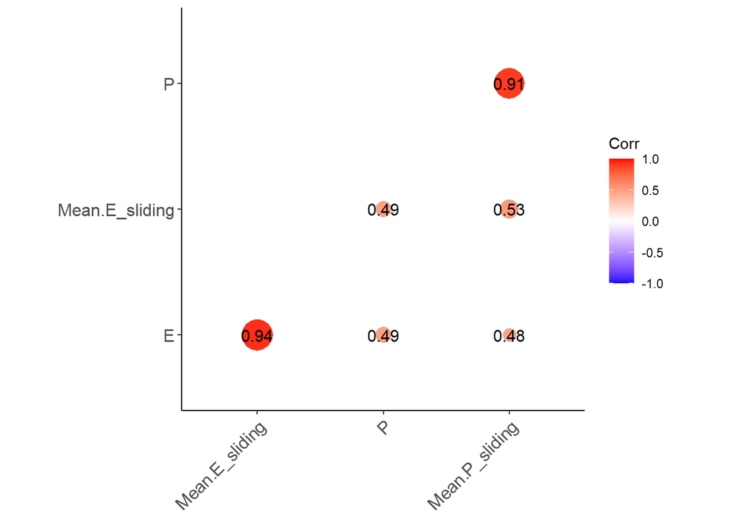

```r
# here we plot the correlations with ggcorrplot
ds %>%
  ungroup() %>%
  select(E, Mean.E_sliding, E_t1.t6, P, Mean.P_sliding) %>%
  cor(., use="pairwise.complete.obs")%>%
  ggcorrplot::ggcorrplot(
                          show.legend = TRUE, type="lower", method = "circle", lab=TRUE,
                          ggtheme = ggplot2::theme_classic)
```

We often observe better correlations between P and E averaged over multiple timepoints, presumably reflecting that the averaged scores better represent the actual amount of stressors faced (while individual scores include more noise). That pattern is often much more pronounced than here.

```
  Task 1.1.3b Plot E, E_sliding, P and P_sliding per subject over time, using the lattice function "xyplot"
```

Note: in the console, you may have to use the function “zoom” to see the plots properly

[figure not shown]

```r
lattice::xyplot(ds$P ~ as.factor(ds$beep)| ds$subject.ID, data = ds, type = c("p", "l"), col ="blue", col.line="black", xlab="beep", ylab="P", main="P per beep")
```

[figure not shown]

```r
lattice::xyplot(ds$Mean.P_sliding ~ as.factor(ds$beep)| ds$subject.ID, data = ds, type = c("p", "l"), col ="blue", col.line="black", xlab="beep", ylab="P", main="P sliding")
```

[figure not shown]

```r
lattice::xyplot(ds$E ~ as.factor(ds$beep)| ds$subject.ID, data = ds, type = c("p", "l"), col ="blue", col.line="black", xlab="beep", ylab="P", main="E per beep")
```

[figure not shown]

```
  Task 1.1.3c Plot SR and SR_sliding per subject over time, using the lattice function "xyplot"
```

```r
lattice::xyplot(ds$Mean.E_sliding ~ as.factor(ds$beep)| ds$subject.ID, data = ds, type = c("p", "l"), col ="blue", col.line="black", xlab="beep", ylab="P", main="E sliding")
```

[figure not shown]

```r
lattice::xyplot(ds$SR ~ as.factor(ds$beep)| ds$subject.ID, data = ds, type = c("p", "l"), col ="blue", col.line="black", xlab="beep", ylab="P", main="SR per beep")
```

[figure not shown]

```r
lattice::xyplot(ds$SR_sliding ~ as.factor(ds$beep)| ds$subject.ID, data = ds, type = c("p", "l"), col ="blue", col.line="black", xlab="beep", ylab="SR", main="SR sliding")
```

As expected, the sliding windows produce much smoother trajectories - which may or may not be desired, depending on the data quality and research question.

TIP: in some cases, it can also be desired to build an SR for one sliding window, and then recycle this E-P line to apply to subsequent windows. Building such a reference line can be used to track actual group-level changes in SR over time, e.g. relative to a given baseline.